# 第零章：课程环境搭建与工具准备

章节作者：刘贇喆 | 华东师范大学 社会发展学院

更新时间：2026-10-10

章节概述

第 0 章用于完成本课程的计算环境准备。**R** 是用于统计计算与数据分析的软件环境，**RStudio** 则提供代码编辑、运行、绘图和项目管理界面。理解二者的功能分工，有助于正确安装软件并建立后续课程所需的工作环境。

本章依次介绍 Windows 与 macOS 系统下的软件下载与安装、Console 基础测试，以及编辑器外观和 CRAN 软件包仓库设置。环境配置以“可运行、可检查”为完成标准：基础代码能够执行，R 与 RStudio 的版本信息能够读取，CRAN 仓库地址能够识别。

# **本章学习内容**

## **学习导航**

**本章学习内容**

第 0 章包含以下五个学习单元。选择 **下方导航卡** 可进入相应小节：

全景认知

R 与 RStudio

软件下载

获取官方安装包

软件安装

分系统图解安装

环境测试

Hello World

自定义

Global Options

**提示**：完成一个小节后，可使用右侧“本节工具”返回学习导航；进入下载或安装子页时，该工具会同时提供相应的返回导航入口。

## **1.0 R 与 RStudio**

### **1.0 R 与 RStudio**

#### **1.1 R 语言概述**

R 是用于统计计算、数据分析与图形表达的开源语言和软件环境。其功能可以通过扩展包持续补充，适合记录并复现完整的分析过程。

#### R 的起源与演进

R 语言由 Ross Ihaka 和 Robert Gentleman 于 1990 年代初在新西兰奥克兰大学共同开发，其名称与两位作者名字的首字母有关 (Ihaka & Gentleman, 1996)。R 延续了贝尔实验室 S 语言的设计思想，并以自由软件的方式发展。

R 既是一门编程语言，也是一个统计计算环境。R 本身可以免费使用，研究者和开发者还可以通过扩展包补充数据处理、建模、可视化与报告生成等功能。

R 以代码驱动的操作方式 (Script-based) 为主，本课程也将数据处理、分析和制图步骤写入脚本。脚本可以保存、检查并重新运行，有助于记录分析过程；要完整复现结果，还需同时保留数据、软件版本和必要的分析说明。

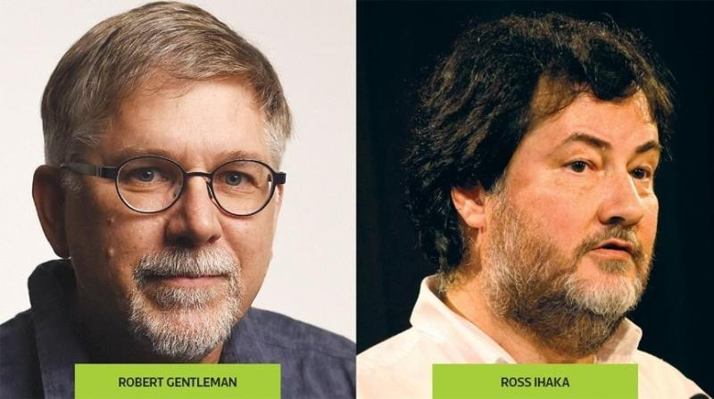

R 语言创始人 Robert Gentleman 与 Ross Ihaka

#### R 的主要应用领域

R 的用途并不限于统计检验，还包括数据整理、机器学习、空间分析、可视化和自动化报告。

**1. 学术科研：**

- **计算社会科学** (CSS)：文本挖掘、网络舆情分析、社会网络分析 (SNA)
- **地理数据科学**：空间不平等研究、社区隔离分析、人口流动制图
- **公共卫生与流行病学**：生存分析、健康不平等研究、因果推断
- **数据可视化**：基于 `ggplot2` 制作结构清晰、便于修改的学术图表

**2. 业界应用：**

- **数据科学与挖掘**：用户行为分析、推荐算法、A/B 测试
- **金融与量化分析**：风险建模、量化投资策略、精算分析
- **智库与商业分析**：处理调查数据，利用 R Markdown 生成可更新的商业或政策评估报告

#### R 的现代数据分析生态

R 提供了从数据清洗到模型评估的多种工具。选择工具时，应同时考虑数据规模、分析目标和计算资源：

- **数据处理**：`tidyverse` 提供了强调可读性与一致性的整洁数据语法 (Data Wrangling)；`data.table` 适合高效处理较大的表格数据。实际可处理的数据量仍受内存、磁盘和任务复杂度影响。
- **机器学习生态**：
  - **统一工作流**：`tidymodels` 将数据划分、预处理、训练和评估组织在一套较一致的接口中。
  - **算法实现**：R 中可使用 `ranger`、`randomForest`、`xgboost`、`lightgbm`、`e1071` 与 `kernlab` 等包完成常见的分类和回归任务；基础 `stats` 包提供 K-means 和层次聚类算法，`factoextra` 可辅助整理和呈现聚类结果。
- **跨语言协作**：R 可通过 `reticulate` 调用 Python 环境，在同一项目中结合 R 的统计分析工具与 Python 的深度学习框架 (如 PyTorch、TensorFlow)。

#### **为什么本课程使用 R**

本课程选择 R，主要基于以下五项特点。其中第 1 项和第 2 项会贯穿后续章节：

1. **免费与开源** 重要!

   R 与 RStudio Desktop 均可免费使用，能够覆盖本课程的数据处理、统计分析、制图和报告写作任务。开源代码也便于研究者检查函数实现、记录依赖并追踪分析过程。
2. **流程可复现** 重要!

   借助 R Markdown 或 Quarto，可以把“数据清洗、统计建模与结果呈现”写在同一份动态文档中。只要数据和依赖条件保持一致，文档就能重新运行并生成更新后的结果。
3. **系统的可视化工具**

   `ggplot2` 基于“图形语法”组织图层、映射和标度，既适合快速探索，也能通过主题和注释制作符合学术规范的图表。
4. **扩展包与社区支持**

   CRAN 收录了覆盖基础统计、空间分析、文本分析和机器学习等领域的扩展包。各扩展包的官方文档，以及 Stack Overflow、R-bloggers 等社区资源，可用于学习和排查常见问题。
5. **与学术方法发展衔接**

   R 与学术研究联系紧密，许多统计方法会以 R 包和配套论文的形式发布。使用新方法时，仍需阅读方法文档，核对假设条件与适用范围。

#### R 还是 Python？

在数据科学领域，R 与 Python 的功能有较多重叠，许多任务均可由两者完成。主要差异体现在**侧重点**与**工具生态**：

- **Python 的优势**：
  - **工程应用与通用性**：作为通用编程语言，Python 在软件开发、自动化脚本及模型部署方面应用较为成熟。
  - **深度学习与 AI**：Python 在人工智能开发中应用广泛，并拥有 PyTorch、TensorFlow、Keras 等成熟框架和大语言模型调用接口。
  - **数据获取与爬虫**：Python 提供 Scrapy、BeautifulSoup、Selenium 等工具，适合处理规模较大或结构复杂的网页采集任务。
- **R 的优势**：
  - **统计分析**：R 在统计建模、计量经济学和因果推断等领域积累了成熟的扩展包，并能较方便地输出模型诊断与统计结果。
  - **学术可视化**：`ggplot2` 及其扩展包便于统一图形语法、主题和版式，适合制作需要反复修改的学术图表。
  - **轻量级数据采集**：`rvest` 可完成常见静态网页的解析，适合规模适中的研究型数据采集任务。

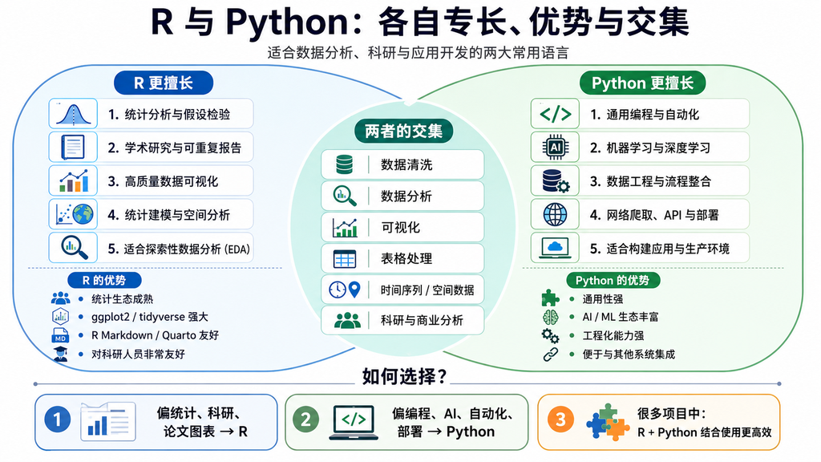

R 与 Python

【学习建议】 本课程采用 **“R 为主，Python 为辅”** 的学习路线：先用 R 掌握数据处理、统计分析和可视化，再根据研究问题补充 Python 的自动化、深度学习或大模型工具。

#### **1.2 认识 RStudio**

#### 什么是 RStudio？

RStudio 是面向 R 的 **集成开发环境** (IDE)，由 **Posit PBC** (原 RStudio 公司) 开发。它把代码编辑、运行、调试、绘图和帮助文档集中在同一界面中，便于组织分析流程。

Posit 同时提供商业产品和服务；本课程使用的 **RStudio Desktop 开源版** 可以免费下载，已能满足课堂学习和一般研究分析的需要。

#### R 与 RStudio 的协作机制

- **依赖关系**：RStudio 需要调用 R 执行代码，因此应先安装 R
- **直观类比**：R 可视为汽车的 **引擎** ，RStudio 则相当于 **仪表盘与操纵杆**
- **工作流程**：在 RStudio 中编写指令 $\rightarrow$ 发送给底层的 R 执行 $\rightarrow$ R 将计算结果返回 RStudio 界面进行展示

[figure not shown]

R 与 RStudio 的协作关系

#### 为什么选择 RStudio？

主要功能

R 自带的图形界面 (如 Windows 上的 RGui) 可以直接运行代码，但代码编辑、绘图和帮助文档较为分散。RStudio 将这些功能放在一个界面中，更适合初学者建立稳定的工作流程。

RStudio 通常以“四窗格”方式组织这些功能 (后续章节将详细介绍)，并提供项目管理与文档写作支持：

- **Source** (代码编辑区)：编写脚本、笔记与文档 (包括本课程使用的 R Markdown)。
- **Console** (控制台)：交互式执行代码，即时查看运行结果或报错信息。
- **Environment** (环境面板)：管理当前会话中的数据集、变量与对象。
- **Files / Plots / Packages** (辅助面板)：管理项目文件、预览图形输出以及安装或更新扩展包。

注意 本课程后续的课堂演示、作业与考核统一在 **RStudio** 环境中完成。

[figure not shown]

本课程使用 RStudio 作为主要开发环境

## **2.0 软件下载**

### **2.0 软件下载**

**版本与截图说明**：R 与 RStudio Desktop 会持续更新，建议从官方网站下载当前稳定版。本章部分下载截图记录的是页面制作时的 R 4.6.1 与 RStudio 2026.09.0，安装向导截图还可能来自其他版本。截图仅用于说明入口位置、操作顺序和常见选项；版本号、文件名、系统要求、页面布局及按钮位置均以官网和实际安装向导为准。

#### 2.1 下载 R 与 RStudio

##### 选择操作系统

**R 与 RStudio 下载导航**

选择操作系统后进入对应的下载说明

Windows 系统

下载说明

macOS 系统

下载说明

**提示**：如需切换系统说明，可返回本页签重新选择。

##### Windows 系统

下载 R

官方地址：[打开 CRAN Windows 下载目录](https://cran.r-project.org/bin/windows/) （建议在新标签页中打开）

**操作步骤**：

Step 1 在 Windows 下载目录页点击 **install R for the first time**（首次安装 R）。

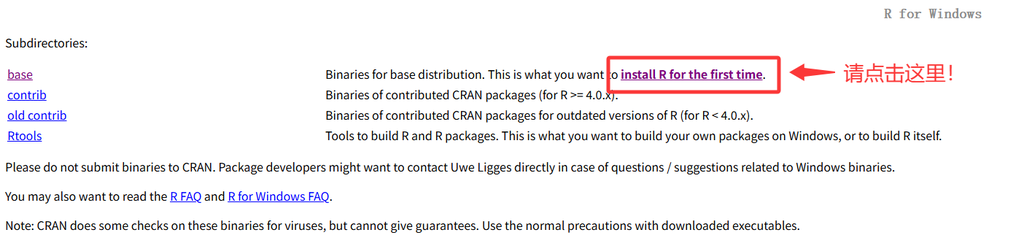

CRAN Windows 下载目录中的首次安装入口

Step 2 点击 **Download R-x.y.z for Windows**（`x.y.z` 会随当前版本变化），保存 `.exe` 安装文件。

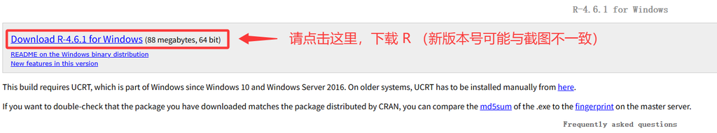

CRAN Windows 下载页中的 R 安装程序

下载 RStudio

Posit 当前下载页将 Windows 11 列为支持的桌面系统。学校机房或较旧的电脑应先核对系统版本和安装权限；后续如有更新，以官方页面列出的系统要求为准。

官方地址：[打开 RStudio Desktop 官方下载页](https://docs.posit.co/ide/user/#rstudio-ide-oss-downloads) （Posit 用户指南）

**操作步骤**：

Step 1 在下载表中找到 **Windows 11**，点击对应的 `.exe` 文件。截图用于识别下载入口，文件名和版本号以下载页当前显示的信息为准。

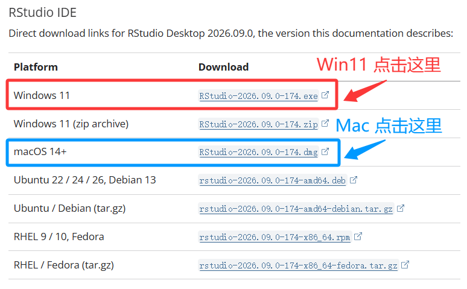

RStudio Desktop 官方下载页中的 Windows 安装包

##### macOS 系统

下载 R

官方地址：[打开 CRAN macOS 下载目录](https://cran.r-project.org/bin/macosx/) （建议在新标签页中打开）

**操作步骤**：

Step 1 先点击屏幕左上角苹果菜单 → **About This Mac**（关于本机）查看芯片类型，再选择对应安装包：

- Apple silicon（M 系列芯片）：下载文件名含 `arm64` 的 `.pkg`；
- Intel 芯片：下载文件名含 `x86_64` 的 `.pkg`。

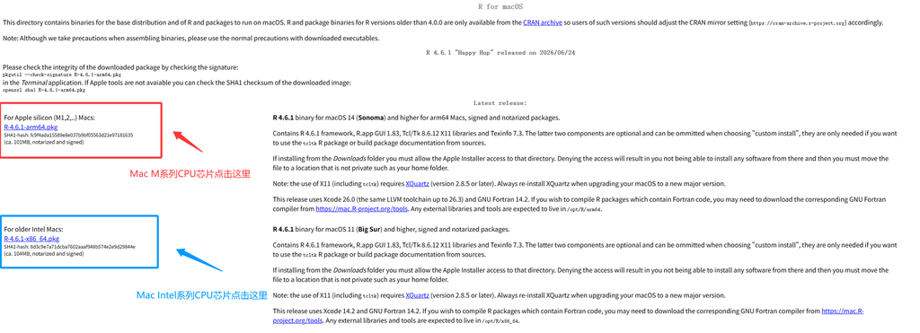

macOS 系统下载 R：根据芯片类型选择安装包

下载 RStudio

Posit 当前下载页将 macOS 14 及以上版本列为支持的桌面系统。较旧的 macOS 应先核对系统要求；后续如有更新，以官方页面列出的系统要求为准。

官方地址：[打开 RStudio Desktop 官方下载页](https://docs.posit.co/ide/user/#rstudio-ide-oss-downloads) （Posit 用户指南）

**操作步骤**：

Step 1 在下载表中找到 **macOS**，点击对应的 `.dmg` 文件。Windows 与 macOS 使用同一下载表；截图用于识别下载入口，系统版本、文件名和软件版本以下载页当前显示的信息为准。

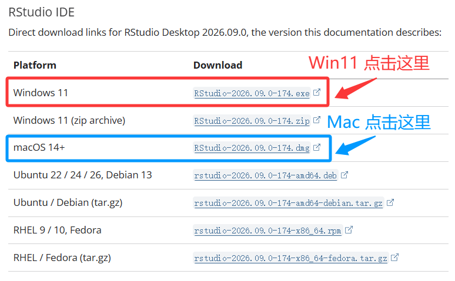

RStudio Desktop 官方下载页中的 macOS 安装包

## **3.0 软件安装**

### **3.0 软件安装**

**安装截图说明**：下列截图用于说明安装顺序与常见选项，不要求界面与当前版本完全一致。不同软件版本、系统语言和权限设置可能新增、合并或省略部分步骤；操作时应阅读当前安装向导，并以实际显示的按钮和提示为准。

#### 3.1 安装 R 与 RStudio

##### 选择操作系统

**软件安装导航**

选择操作系统后进入对应的安装教程

Windows 系统

安装步骤与配置

macOS 系统

安装步骤与配置

**提示**：如需切换系统教程，可返回本页签重新选择。

##### Windows 系统

安装 R

操作流程（共 9 步）

> 先完成 R 的安装，再安装 RStudio。

Step 1 打开文件资源管理器中的 **下载** 文件夹，找到并双击 R 安装程序（文件名以 `.exe` 结尾，版本号可能与截图不同）。

[figure not shown]

在 Windows 下载文件夹中打开 R 安装程序

Step 2 选择安装程序使用的语言，然后点击 **确定**。

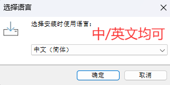

选择 R 安装程序使用的语言

Step 3 阅读许可信息，点击 **下一步**。

[figure not shown]

阅读 R 许可信息并继续安装

Step 4 通常保留默认安装位置；如需自定义位置，可在此修改。确认后点击 **下一步**。

[figure not shown]

选择 R 的安装位置

Step 5 保留默认组件，点击 **下一步**。

[figure not shown]

选择 R 的安装组件

Step 6 选择 **No**（接受默认选项），点击 **下一步**。

[figure not shown]

保留 R 的默认启动选项

Step 7 保留默认开始菜单文件夹，点击 **下一步**。

[figure not shown]

选择 R 的开始菜单文件夹

Step 8 保留默认附加任务，点击 **下一步**开始安装。

[figure not shown]

选择 R 的附加任务

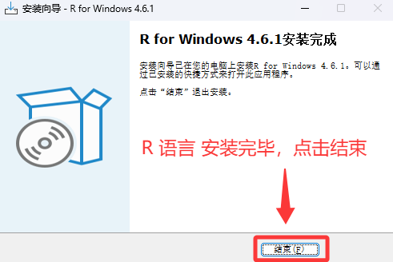

完成 R for Windows 安装

> R 已安装完成。下一步安装 RStudio。

安装 RStudio

操作流程（共 6 步）

> 安装完成后，按 Step 6 启动 RStudio，再进入下一节进行测试。

Step 1 双击下载好的 RStudio 安装文件（文件名以 `.exe` 结尾）。

[figure not shown]

在 Windows 下载文件夹中打开 RStudio 安装程序

Step 2 在安装向导中点击 **下一步**。

[figure not shown]

进入 RStudio 安装向导

Step 3 建议保留 **For anyone who uses this computer (all users)**（为所有使用者安装）的默认选项，然后点击 **下一步**。该选项可能需要管理员权限；如无管理员权限，可选择仅为当前用户安装。

[figure not shown]

选择 RStudio 的安装用户范围

Step 4 建议保留默认安装位置；如需调整，可点击 **浏览** 选择其他文件夹。确认后点击 **安装**。

[figure not shown]

选择 RStudio 的安装位置并开始安装

Step 5 安装完成后点击 **完成**，关闭安装向导。

[figure not shown]

完成 RStudio for Windows 安装

Step 6 在 Windows 任务栏的搜索框中输入 **RStudio**，从搜索结果中打开应用。

[figure not shown]

在 Windows 中搜索并打开 RStudio

> RStudio 已安装并可正常启动。下一节将检查 R 与 RStudio 是否能够协同运行。

##### macOS 系统

安装 R

操作流程（共 5 步）

> 先完成 R 的安装，再安装 RStudio。

Step 1 双击下载好的 R 安装包（文件名以 `.pkg` 结尾）。

[figure not shown]

打开 macOS 的 R 安装包

Step 2 在安装器的介绍页面点击 **继续**。

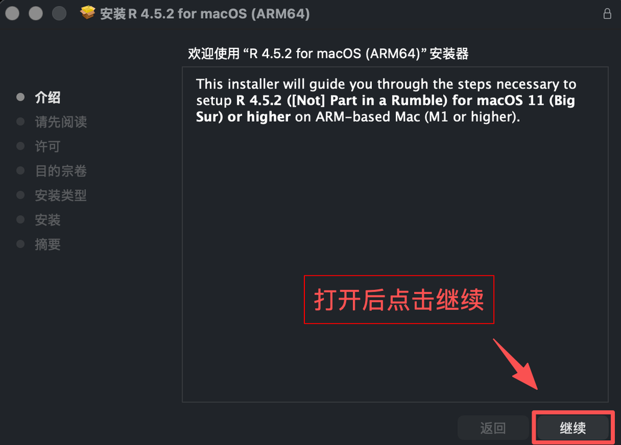

进入 R 安装器的介绍页面

Step 3 阅读“请先阅读”信息，点击 **继续**。

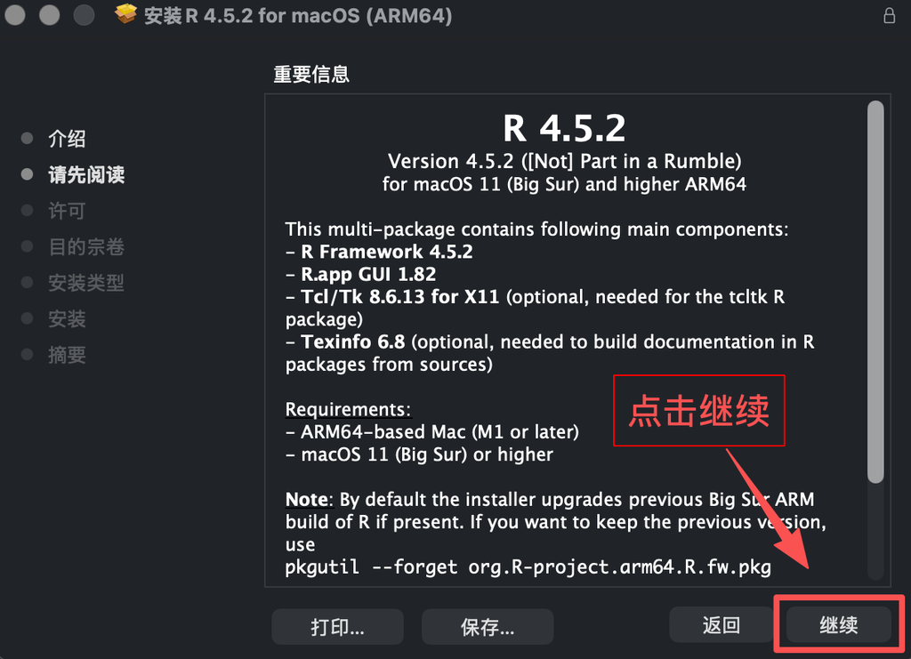

阅读 R 安装器中的说明信息

Step 4 阅读软件许可协议，点击 **继续**，并在弹窗中选择 **同意**。

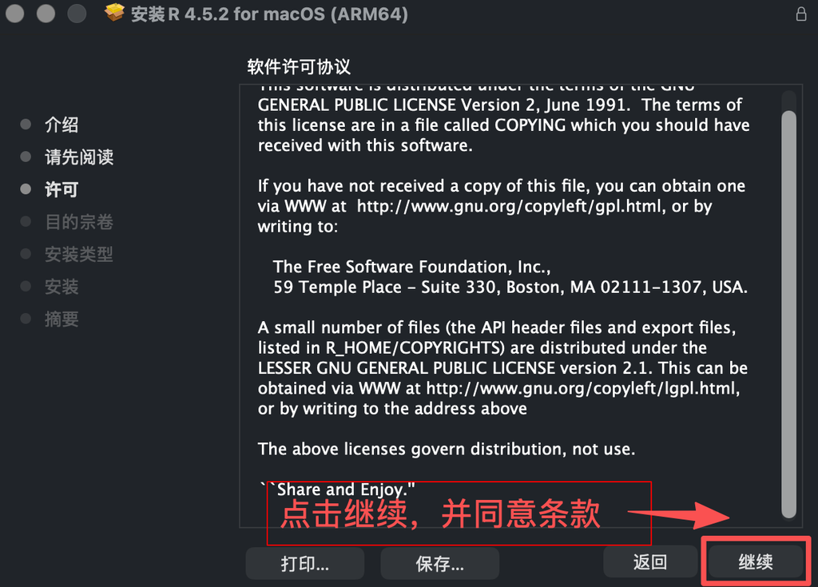

阅读并接受 R 软件许可协议

Step 5 保留默认安装位置，点击 **安装**；按系统提示输入密码或使用 Touch ID，等待安装完成。

[figure not shown]

确认 R 的安装位置并开始安装

安装 RStudio

操作流程（共 2 步）

> 完成下列两步后，即可进入下一节测试运行环境。

Step 1 双击下载好的 RStudio 磁盘映像（文件名以 `.dmg` 结尾）。

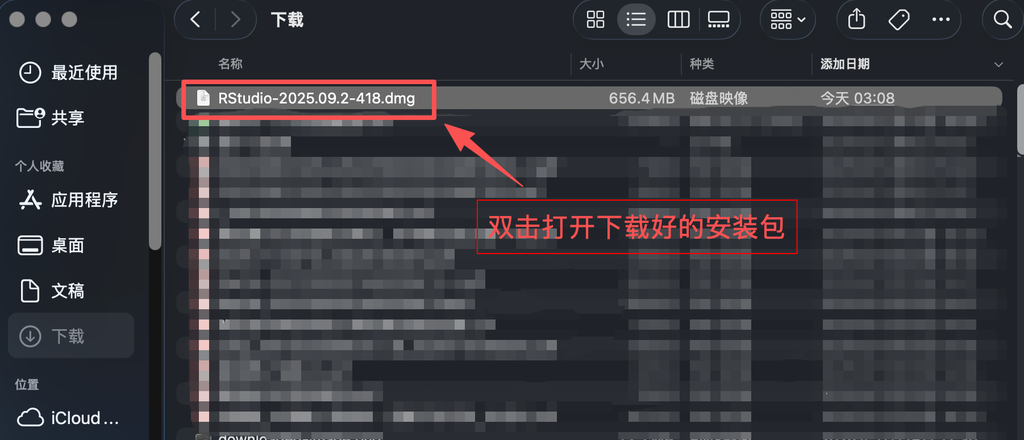

打开 RStudio 的 macOS 磁盘映像

Step 2 将 **RStudio** 图标拖入 **Applications**（应用程序）文件夹，再从该文件夹启动 RStudio。

[figure not shown]

将 RStudio 拖入 Applications 文件夹